# Loading the data.

- First unzip the file and load the data into a variable called “data”.
- Take a quick look at the first 10 rows.

```r
unzip("activity.zip")
data <- read.csv("activity.csv")
head(data, 10)
```

```
##    steps       date interval
## 1     NA 2012-10-01        0
## 2     NA 2012-10-01        5
## 3     NA 2012-10-01       10
## 4     NA 2012-10-01       15
## 5     NA 2012-10-01       20
## 6     NA 2012-10-01       25
## 7     NA 2012-10-01       30
## 8     NA 2012-10-01       35
## 9     NA 2012-10-01       40
## 10    NA 2012-10-01       45
```

# Total Number of Steps per Day

- Load dplyr package
- Limit the data to where we don’t have any N/A’s.
- Group the data by date and sum up.
- Plot histogram of the total number of steps per day.

```r
library(dplyr)
data <- data[complete.cases(data),]
by_day <- data %>% group_by(date) %>% summarise(total = sum(steps))
head(by_day, 10)
```

```
## # A tibble: 10 x 2
##    date       total
##    <chr>      <int>
##  1 2012-10-02   126
##  2 2012-10-03 11352
##  3 2012-10-04 12116
##  4 2012-10-05 13294
##  5 2012-10-06 15420
##  6 2012-10-07 11015
##  7 2012-10-09 12811
##  8 2012-10-10  9900
##  9 2012-10-11 10304
## 10 2012-10-12 17382
```

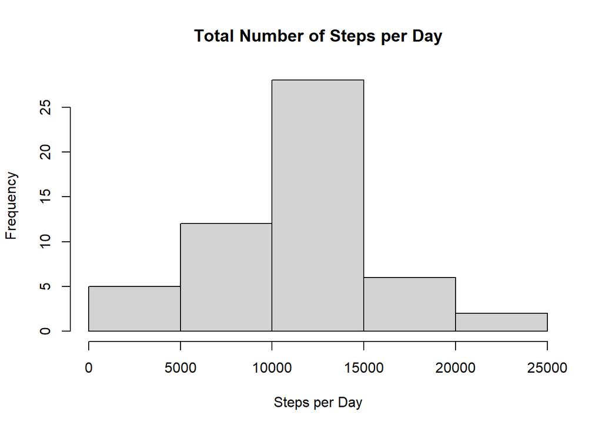

```r
hist(by_day$total, main = "Total Number of Steps per Day", xlab = "Steps per Day")
```

# Mean and Median

[output not shown]

[output not shown]

- The mean number of steps is 10,766 and the median number of steps is 10,765.

```r
summary(by_day$total)
```

```
##    Min. 1st Qu.  Median    Mean 3rd Qu.    Max.
##      41    8841   10765   10766   13294   21194
```

# Average Daily Activity Pattern

- First we group the data by interval and then calculate the average number of steps.
- Next we plot this data with the interval on the x-axis and the average number of steps on the y-axis.
- Next we find the interval with the highest average number of steps. This occurs on interval 835.

```r
average_by_interval <- data %>% group_by(interval) %>% summarise(average_steps = mean(steps))
head(average_by_interval)
```

```
## # A tibble: 6 x 2
##   interval average_steps
##      <int>         <dbl>
## 1        0        1.72
## 2        5        0.340
## 3       10        0.132
## 4       15        0.151
## 5       20        0.0755
## 6       25        2.09
```

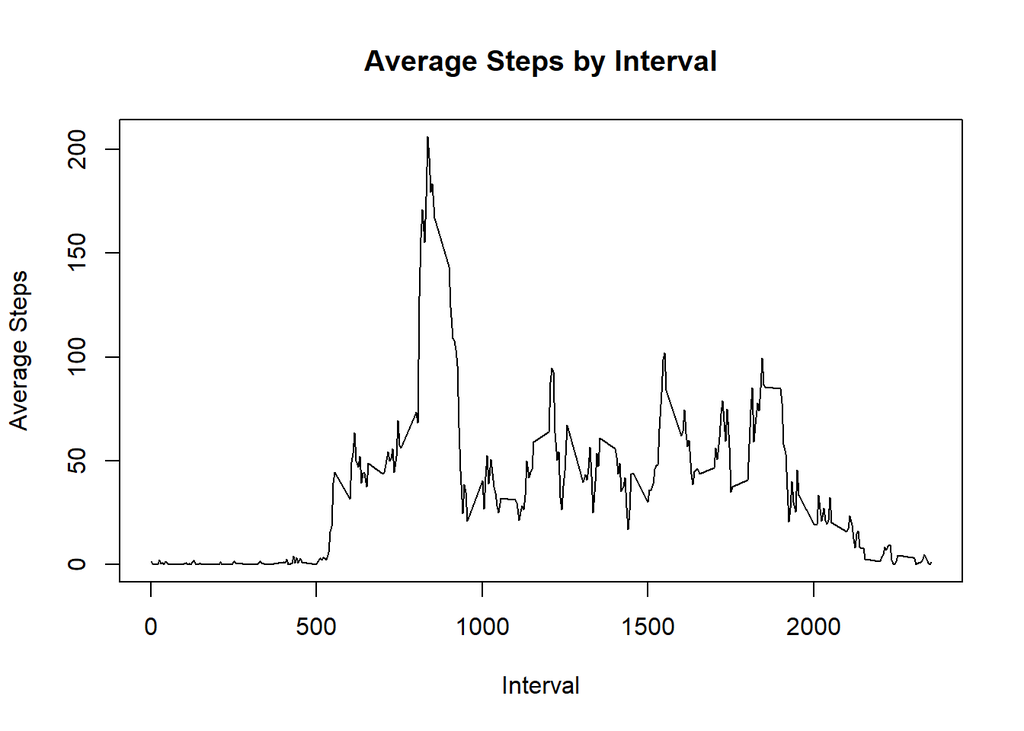

```r
plot(average_by_interval$interval, average_by_interval$average_steps, type = "l", xlab = "Interval", ylab = "Average Steps", main = "Average Steps by Interval")
```

```r
average_by_interval[which.max(average_by_interval$average_steps),]
```

```
## # A tibble: 1 x 2
##   interval average_steps
##      <int>         <dbl>
## 1      835          206.
```

# Imputing Missing Values

- First I’m going to load the data again because I removed the rows with NA values earlier.
- Next we calculate the number of rows with missing values.
- There are 2,304 rows with missing values.
- Next to fill in the missing N/A values.
- We’ll first merge the average numbers of steps by interval we calculated earlier to the data table with the missing N/A values.
- Then we replace the missing values with the average number of steps for that time interval.
- Next we just clean up the dataset a bit by removing the average steps and putting the new data in a new variable.
- We then repeat our earlier steps of creating a histogram and calculating the mean and median number of steps per day.
- We can see that the new mean is 10,766 and the new median is 10,766. While the mean number of steps hasn’t seen a material change, the median has seen a slight increase.

```r
data_with_na <- read.csv("activity.csv")
head(data_with_na, 10)
```

```
##    steps       date interval
## 1     NA 2012-10-01        0
## 2     NA 2012-10-01        5
## 3     NA 2012-10-01       10
## 4     NA 2012-10-01       15
## 5     NA 2012-10-01       20
## 6     NA 2012-10-01       25
## 7     NA 2012-10-01       30
## 8     NA 2012-10-01       35
## 9     NA 2012-10-01       40
## 10    NA 2012-10-01       45
```

```r
sum(is.na(data_with_na))
```

```
## [1] 2304
```

```r
merged_table <- merge(data_with_na, average_by_interval, by= "interval")
head(merged_table)
```

```
##   interval steps       date average_steps
## 1        0    NA 2012-10-01      1.716981
## 2        0     0 2012-11-23      1.716981
## 3        0     0 2012-10-28      1.716981
## 4        0     0 2012-11-06      1.716981
## 5        0     0 2012-11-24      1.716981
## 6        0     0 2012-11-15      1.716981
```

```r
merged_table$steps <- ifelse(is.na(merged_table$steps), merged_table$average_steps, merged_table$steps)
head(merged_table, 10)
```

```
##    interval    steps       date average_steps
## 1         0 1.716981 2012-10-01      1.716981
## 2         0 0.000000 2012-11-23      1.716981
## 3         0 0.000000 2012-10-28      1.716981
## 4         0 0.000000 2012-11-06      1.716981
## 5         0 0.000000 2012-11-24      1.716981
## 6         0 0.000000 2012-11-15      1.716981
## 7         0 0.000000 2012-10-20      1.716981
## 8         0 0.000000 2012-11-16      1.716981
## 9         0 0.000000 2012-11-07      1.716981
## 10        0 0.000000 2012-11-25      1.716981
```

```r
merged_table <- merged_table[order(merged_table$date),]

new_dataset <- select(merged_table,1:3) %>% arrange(date)
head(new_dataset)
```

```
##   interval     steps       date
## 1        0 1.7169811 2012-10-01
## 2        5 0.3396226 2012-10-01
## 3       10 0.1320755 2012-10-01
## 4       15 0.1509434 2012-10-01
## 5       20 0.0754717 2012-10-01
## 6       25 2.0943396 2012-10-01
```

```r
by_day_new_dataset <- new_dataset %>% group_by(date) %>% summarise(total = sum(steps))
head(by_day_new_dataset, 10)
```

```
## # A tibble: 10 x 2
##    date        total
##    <chr>       <dbl>
##  1 2012-10-01 10766.
##  2 2012-10-02   126
##  3 2012-10-03 11352
##  4 2012-10-04 12116
##  5 2012-10-05 13294
##  6 2012-10-06 15420
##  7 2012-10-07 11015
##  8 2012-10-08 10766.
##  9 2012-10-09 12811
## 10 2012-10-10  9900
```

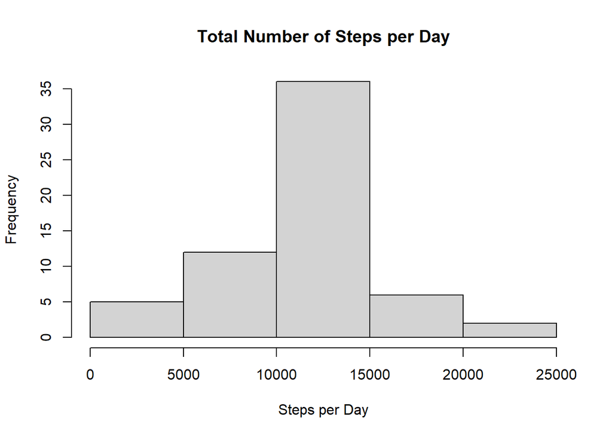

```r
hist(by_day_new_dataset$total, main = "Total Number of Steps per Day", xlab = "Steps per Day")
```

```r
summary(by_day_new_dataset$total)
```

```
##    Min. 1st Qu.  Median    Mean 3rd Qu.    Max.
##      41    9819   10766   10766   12811   21194
```

# Weekdays vs Weekends

- First creating a copy of our new dataset with the imputed values so as to not mess up the original dataset.
- Next calculate the day of the week and then create a new column with whether it is a weekday or weekend.
- Convert to factor.
- Calculate the average by grouping by interval and weekend/weekday.
- Create a panel graph showing average number of steps by interval on weekdays vs weekends.

```r
new_dataset2 <- new_dataset
head(new_dataset2)
```

```
##   interval     steps       date
## 1        0 1.7169811 2012-10-01
## 2        5 0.3396226 2012-10-01
## 3       10 0.1320755 2012-10-01
## 4       15 0.1509434 2012-10-01
## 5       20 0.0754717 2012-10-01
## 6       25 2.0943396 2012-10-01
```

```r
new_dataset2$date <- as.Date(new_dataset2$date)
new_dataset2$day <- weekdays(new_dataset2$date)
new_dataset2$weekday <- ifelse(new_dataset2$day == "Saturday" | new_dataset2$day == "Sunday", "Weekend", "Weekday")
head(new_dataset2, 10)
```

```
##    interval     steps       date    day weekday
## 1         0 1.7169811 2012-10-01 Monday Weekday
## 2         5 0.3396226 2012-10-01 Monday Weekday
## 3        10 0.1320755 2012-10-01 Monday Weekday
## 4        15 0.1509434 2012-10-01 Monday Weekday
## 5        20 0.0754717 2012-10-01 Monday Weekday
## 6        25 2.0943396 2012-10-01 Monday Weekday
## 7        30 0.5283019 2012-10-01 Monday Weekday
## 8        35 0.8679245 2012-10-01 Monday Weekday
## 9        40 0.0000000 2012-10-01 Monday Weekday
## 10       45 1.4716981 2012-10-01 Monday Weekday
```

```r
new_dataset2$weekday <- as.factor(new_dataset2$weekday)

AverageByIntervalAndDay <- new_dataset2 %>% group_by(interval, weekday) %>% summarise(average_steps = mean(steps))
head(AverageByIntervalAndDay)
```

```
## # A tibble: 6 x 3
## # Groups:   interval [3]
##   interval weekday average_steps
##      <int> <fct>           <dbl>
## 1        0 Weekday        2.25
## 2        0 Weekend        0.215
## 3        5 Weekday        0.445
## 4        5 Weekend        0.0425
## 5       10 Weekday        0.173
## 6       10 Weekend        0.0165
```

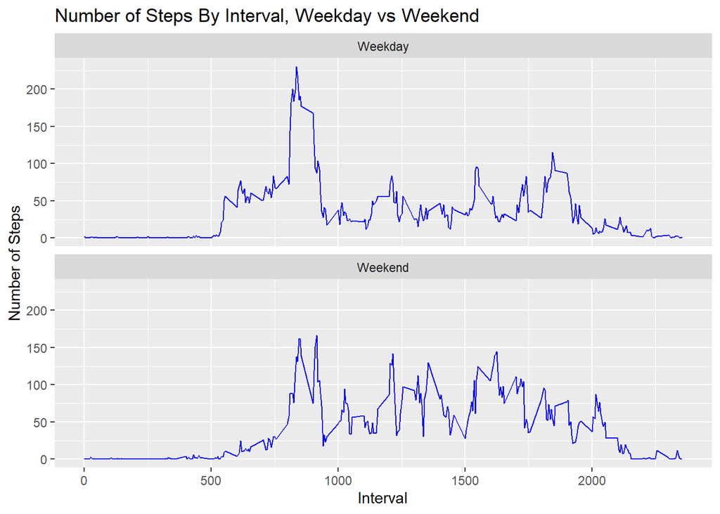

```r
library(ggplot2)
ggplot(data = AverageByIntervalAndDay, aes(interval, average_steps)) + geom_line(color = "blue") + labs(title = "Number of Steps By Interval, Weekday vs Weekend", y = "Number of Steps", x = "Interval") + facet_wrap(~ weekday, ncol = 1)
```